# Assignment 2

Author

Your Name

Published

September 13, 2024

# Instructions

Please submit your assignment as html file to me via email. Please call your assignment: “yourname_assignment2.html”. For example, I would submit something called “popescu_assignment2.html”. Please make sure that it is all in lower case.

To match the appearance of this template, ensure that your assignment preamble or YAML is set up as follows

```yaml
---
title: "Assignment 2"
author: "Your Name"
date: "September 13, 2024"
format:
  html:
    toc: true
    number-sections: true
    colorlinks: true
    smooth-scroll: true
    embed-resources: true
---
```

Important: Headers like “Question” should be marked with a `#` (for example, `# Question`). This will format the text as a bold, larger header when the document is rendered, and it will also appear in the Table of Contents. For regular text, simply write it on the line below the header.

Please answer all the questions below.

# 1 Question

```r
setwd("/Users/bgpopescu/Dropbox/john_cabot/teaching/stats/assignment2/")
life_expectancy <- read.csv(file = './life-expectancy.csv')
urbanization <- read.csv(file = './share-of-population-urban.csv')
```

# 2 Question

Print only the first 4 entries of both datasets.

```r
head(life_expectancy, n=4)
```

```
       Entity Code Year Life.expectancy.at.birth..historical.
1 Afghanistan  AFG 1950                                  27.7
2 Afghanistan  AFG 1951                                  28.0
3 Afghanistan  AFG 1952                                  28.4
4 Afghanistan  AFG 1953                                  28.9
```

```r
head(urbanization, n=4)
```

```
       Entity Code Year Urban.population....of.total.population.
1 Afghanistan  AFG 1960                                    8.401
2 Afghanistan  AFG 1961                                    8.684
3 Afghanistan  AFG 1962                                    8.976
4 Afghanistan  AFG 1963                                    9.276
```

# 3 Question

Create a subset of Latin American countries that has the two variables: life expectancy and urbanization. Calculate the averages by country and then perform a left join based on country. The Latin American country list should include: Belize, Costa Rica, El Salvador, Guatemala, Honduras, Mexico, Nicaragua, Panama, Argentina, Bolivia, Brazil, Chile, Colombia, Ecuador, Guyana, Paraguay, Peru, Suriname, Uruguay, Venezuela, Cuba, Dominican Republic, Haiti.  
**Note**: make sure you calculate country averages before you run this. In other words, you should have for example Afghanistan only once as opposed to Afghanistan in 1990, Afghanistan in 1991, or Afghanistan in 1992, etc.

```r
library("dplyr")
#Step1: Creating averages for all countries
life_expectancy2<-life_expectancy%>%
  group_by(Code, Entity)%>%
  dplyr::summarize(life_expectancy=mean(Life.expectancy.at.birth..historical.))

urbanization2<-urbanization%>%
  group_by(Code)%>%
  dplyr::summarize(urbanization=mean(Urban.population....of.total.population.))

#Step2: Performing a left merge
new_data<-left_join(life_expectancy2, urbanization2, by = c("Code"="Code"))
head(new_data, n=10)
```

```
# A tibble: 10 × 4
# Groups:   Code [1]
   Code  Entity                                  life_expectancy urbanization
   <chr> <chr>                                             <dbl>        <dbl>
 1 ""    Africa                                             49.7         47.7
 2 ""    Americas                                           66.8         47.7
 3 ""    Asia                                               59.2         47.7
 4 ""    Europe                                             69.0         47.7
 5 ""    High-income countries                              73.9         47.7
 6 ""    Land-locked Developing Countries (LLDC)            50.8         47.7
 7 ""    Latin America and the Caribbean                    64.6         47.7
 8 ""    Least developed countries                          49.8         47.7
 9 ""    Less developed regions                             58.4         47.7
10 ""    Less developed regions, excluding China            56.8         47.7
```

```r
#Step3: Selecting the Latin American countries
latam_countries<-c("Belize",
                   "Costa Rica",
                   "El Salvador",
                   "Guatemala",
                   "Honduras",
                   "Mexico",
                   "Nicaragua",
                   "Panama",
                   "Argentina",
                   "Bolivia",
                   "Brazil",
                   "Chile",
                   "Colombia",
                   "Ecuador",
                   "Guyana",
                   "Paraguay",
                   "Peru",
                   "Suriname",
                   "Uruguay",
                   "Venezuela",
                   "Cuba",
                   "Dominican Republic",
                   "Haiti")


latam_countries_df<-subset(new_data, (Entity %in% latam_countries))
head(latam_countries_df, n=5)
```

```
# A tibble: 5 × 4
# Groups:   Code [5]
  Code  Entity    life_expectancy urbanization
  <chr> <chr>               <dbl>        <dbl>
1 ARG   Argentina            65.4         85.3
2 BLZ   Belize               66.0         48.1
3 BOL   Bolivia              52.6         53.7
4 BRA   Brazil               61.1         71.2
5 CHL   Chile                63.3         81.8
```

# 4 Question

Create a histogram for life expectancy for the list of Latin American countries with 10 bins. Use the `geom_histogram` option.

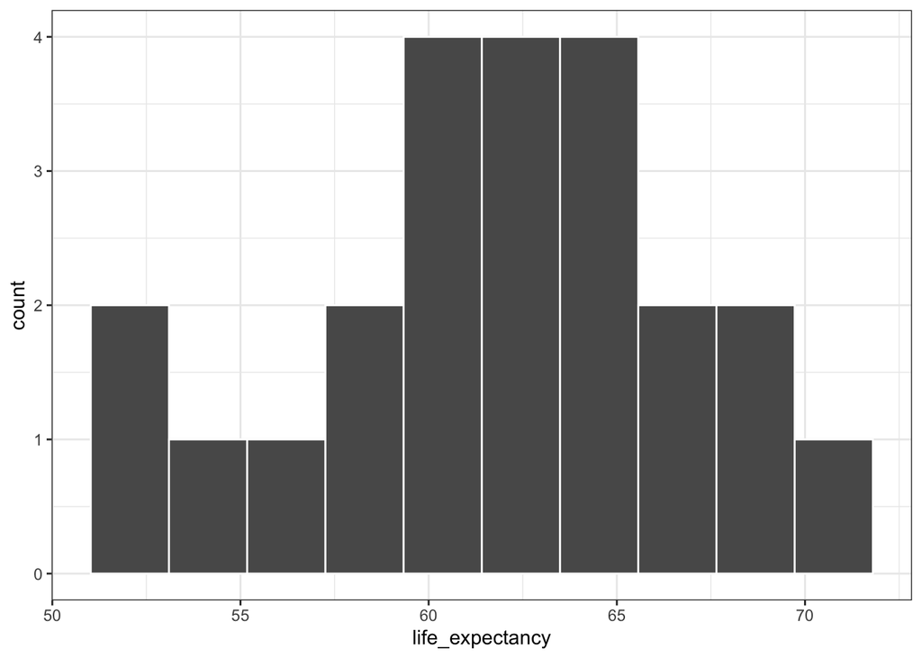

```r
library(ggplot2)
fig1<-ggplot(data = latam_countries_df, aes(x=life_expectancy))+
  geom_histogram(bins = 10, col="white")+
  theme_bw()
fig1
```

# 5 Question

Create a histogram for urbanization for the list of Latin American countries with 10 bins

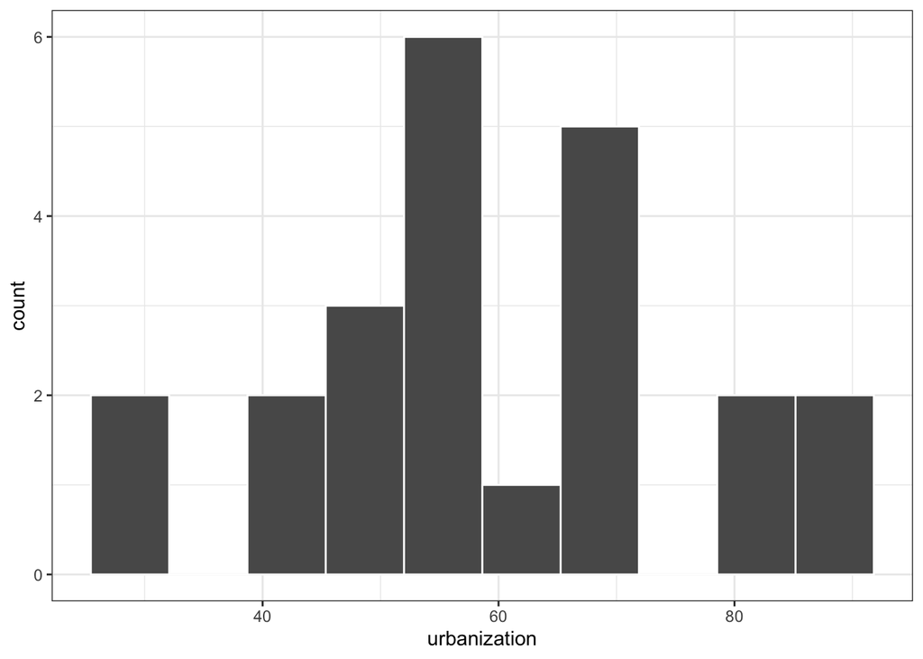

```r
fig2<-ggplot(data = latam_countries_df, aes(x=urbanization))+
  geom_histogram(bins = 10, col="white")+
  theme_bw()
fig2
```

# 6 Question

Put the two histograms side by side using the `grid.arrange` function.

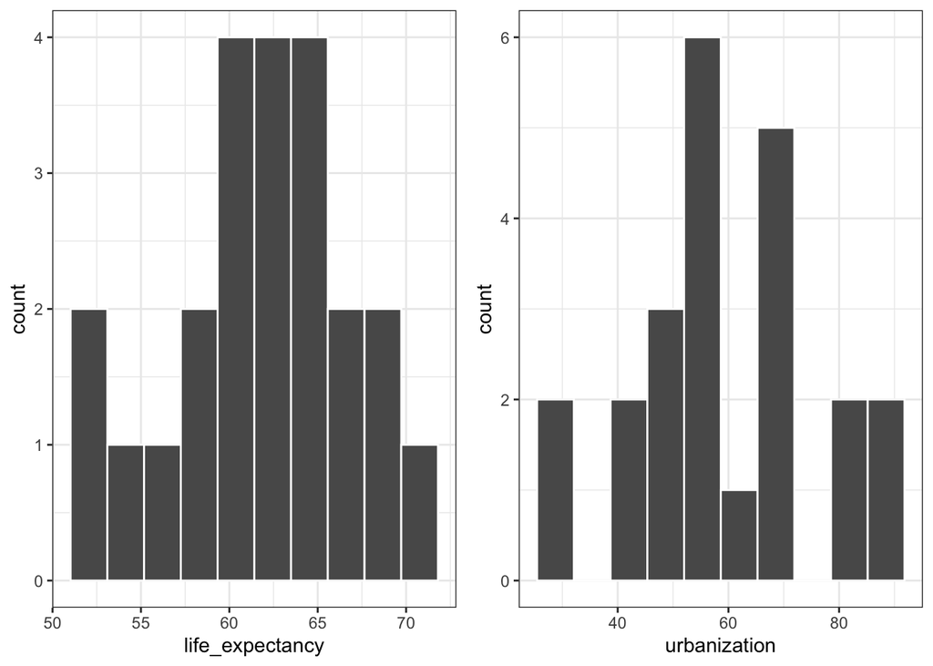

```r
library(gridExtra)
grid.arrange(fig1, fig2, ncol=2)
```

# 7 Question

What is the mean, median, standard deviation, min, and max for the Latin American sample for life expectancy? Just write down the numbers. There is no need for a graph.

The mean is 61.9140352, the median is 63.0055556, the min is 52.0611111, and the max is 70.7636364.

# 8 Question

What is the mean, median, standard deviation, min, and max for the Latin American sample for urbanization? Just write down the numbers. There is no need for a graph.

The mean is 59.0184069, the median is 55.6762621, the min is 28.759623, and the max is 88.4915739.

# 9 Question

Draw a scatterplot in which you examine the relationship between life expectancy and urbanization for the list of Latin American countries. Make sure that the graph meets the following specifications:

- the X and Y axis have to be fixed between 0 and 100
- the X axis should be called “Urbanization” and Y axis should be called “Life Expectancy”
- the title should be “Latin America”

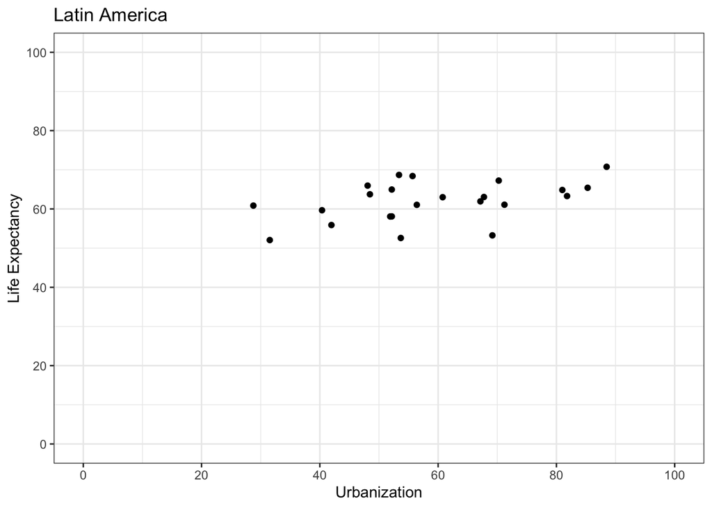

```r
#library("ggplot2")
fig<-ggplot(latam_countries_df, mapping = aes(x=urbanization, y=life_expectancy)) +
  geom_point()+
  xlab("Urbanization") + ylab("Life Expectancy")+
  ggtitle("Latin America")+
  theme_bw()+
  scale_x_continuous(breaks=seq(0, 100, by = 20), limits = c(0,100))+
  scale_y_continuous(breaks=seq(0, 100, by = 20), limits = c(0,100))
fig
```

# 10 Question

Draw a scatterplot in which you examine the relationship between life expectancy and urbanization for the list of Latin American countries. Make sure that the graph meets the following specifications:

- the X and Y axis have to be fixed between 50 and 80
- the X axis should be called “Urbanization” and Y axis should be called “Life Expectancy”
- the title should be “Latin America”

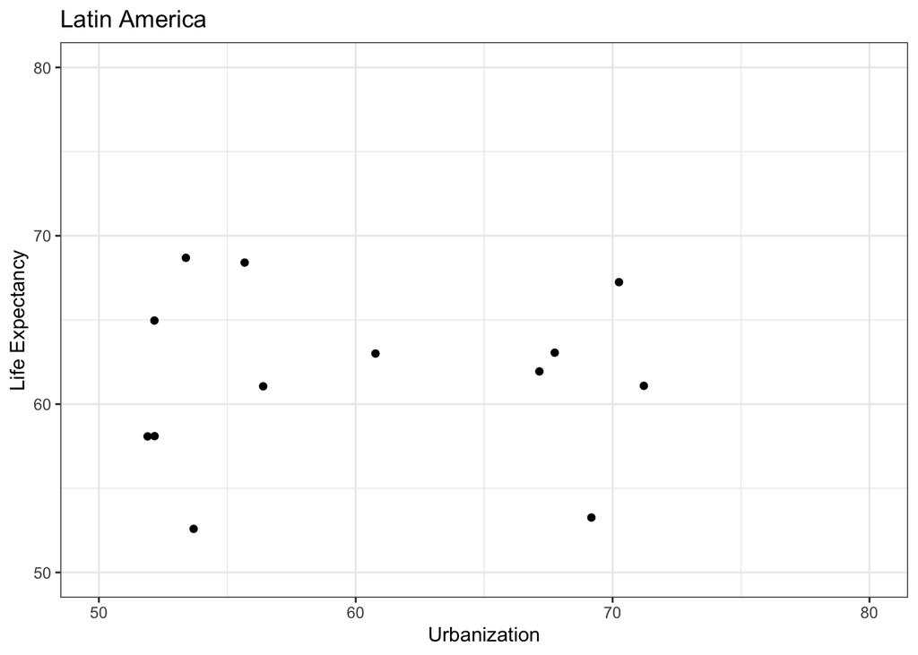

```r
fig<-ggplot(latam_countries_df, mapping = aes(x=urbanization, y=life_expectancy)) +
  geom_point()+
  xlab("Urbanization") + ylab("Life Expectancy")+
  ggtitle("Latin America")+
  theme_bw()+
  scale_x_continuous(breaks=seq(50, 80, by = 10), limits = c(50,80))+
  scale_y_continuous(breaks=seq(50, 80, by = 10), limits = c(50,80))
fig
```

# 11 Question

Fit a line to the same scatter plot in the original scatterplot where the limits of X and Y are 0 and 100, respectively, and interpret it: is there a relationship or is there not between urbanization and life expectancy?

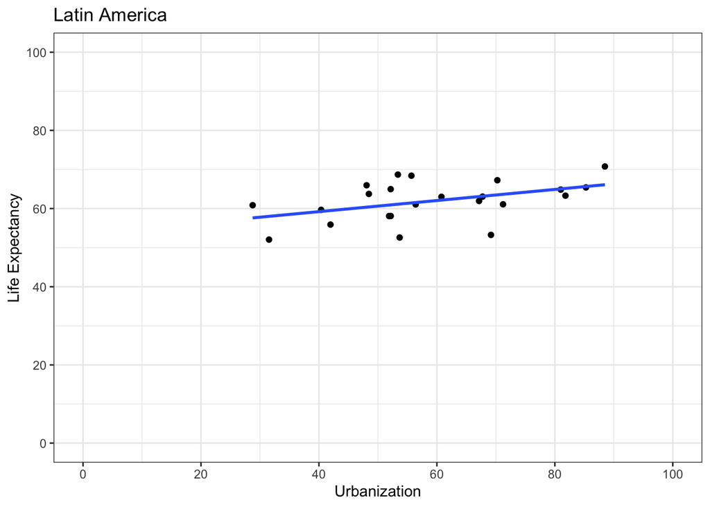

```r
fig<-ggplot(latam_countries_df, mapping = aes(x=urbanization, y=life_expectancy)) +
  geom_point()+
  xlab("Urbanization") + ylab("Life Expectancy")+
  ggtitle("Latin America")+
    geom_smooth(method = "lm", se=FALSE)+
  theme_bw()+
  scale_x_continuous(breaks=seq(0, 100, by = 20), limits = c(0,100))+
  scale_y_continuous(breaks=seq(0, 100, by = 20), limits = c(0,100))
fig
```

Yes, there seems to be a positve relationship between urbanization and life expectancy

# 12 Question

Label all the countries in the graph

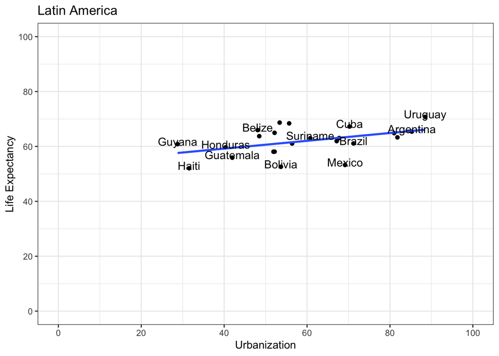

```r
fig<-ggplot(latam_countries_df, mapping = aes(x=urbanization, y=life_expectancy)) +
  geom_point()+
  xlab("Urbanization") + ylab("Life Expectancy")+
  ggtitle("Latin America")+
    geom_smooth(method = "lm", se=FALSE)+
  theme_bw()+
  scale_x_continuous(breaks=seq(0, 100, by = 20), limits = c(0,100))+
  scale_y_continuous(breaks=seq(0, 100, by = 20), limits = c(0,100))+
    geom_text(aes(label = Entity),
            size = 4,
            check_overlap = TRUE,
            position = position_nudge(y = 1),
            data = latam_countries_df)
fig
```

# 13 Question

Label only Brazil and Mexico

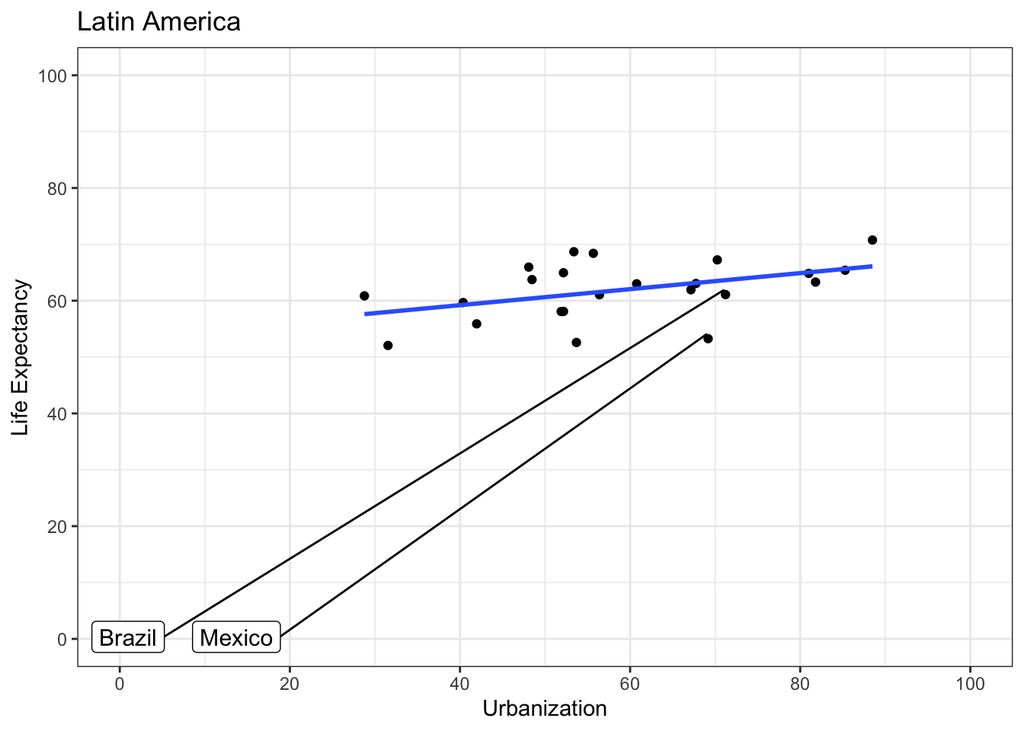

```r
library(ggrepel)
countries_of_interest = c("Brazil", "Mexico")
mexico_brazil_df<-subset(latam_countries_df, Entity %in%  countries_of_interest)


fig<-ggplot(latam_countries_df, mapping = aes(x=urbanization, y=life_expectancy)) +
  geom_point()+
  xlab("Urbanization") + ylab("Life Expectancy")+
  ggtitle("Latin America")+
    geom_smooth(method = "lm", se=FALSE)+
  theme_bw()+
  scale_x_continuous(breaks=seq(0, 100, by = 20), limits = c(0,100))+
  scale_y_continuous(breaks=seq(0, 100, by = 20), limits = c(0,100))+
 geom_label_repel(box.padding = 0.5,
    aes(label = Entity),
            size = 4,
            position = position_nudge(y = 1),
            data = mexico_brazil_df)
fig
```

# 14 Question

Select Italy and the US in from the original dataset and draw a time trend where you depict life expectancy from 1900 until the present day. Make the US blue and Italy red.

```r
countries_of_interest<-c("United States", "Italy")
df_us_italy<-subset(life_expectancy, Entity %in% countries_of_interest)
head(df_us_italy, n=10)
```

```
     Entity Code Year Life.expectancy.at.birth..historical.
8555  Italy  ITA 1872                                 29.70
8556  Italy  ITA 1873                                 31.61
8557  Italy  ITA 1874                                 31.76
8558  Italy  ITA 1875                                 31.33
8559  Italy  ITA 1876                                 33.62
8560  Italy  ITA 1877                                 34.91
8561  Italy  ITA 1878                                 34.34
8562  Italy  ITA 1879                                 33.96
8563  Italy  ITA 1880                                 32.76
8564  Italy  ITA 1881                                 34.21
```

```r
names(df_us_italy)[4]<-"life_expectancy"
```

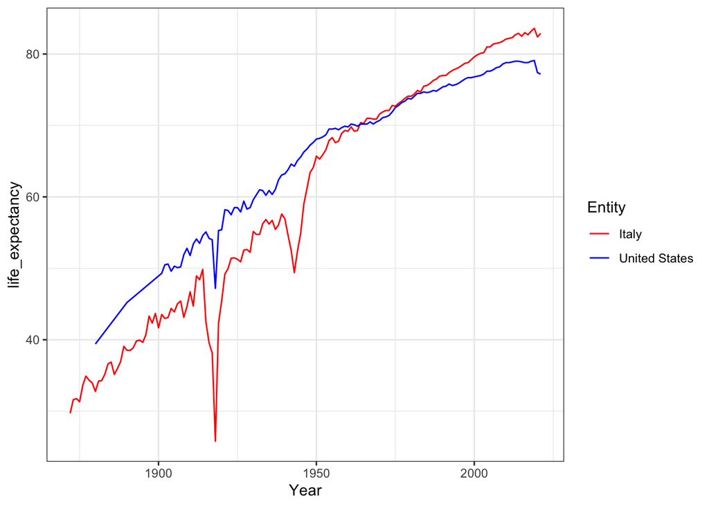

```r
fig<-ggplot(data = df_us_italy, aes(x = Year, y = life_expectancy))+
  geom_line(aes(color = Entity))+
  theme_bw()+
  scale_color_manual(values=c('Red','Blue'))

fig
```

# 15 Question

When is the dip in life expectancy and what could be the cause. Write maximum 5 sentences.

The dip in life expectancy occurs between 1900 and 1950. It is clearly visible for Italy as the dip is significant, however it is notable also for United States. The case could be the fact that they were the years of both the wars, therefore the life exèectancy rate decreased enormously.